# Project: Investigate a Dataset - [No_show Appointments]

- Introduction
- Data Wrangling
- Exploratory Data Analysis
- Conclusions

## Introduction

### Dataset Description

This dataset collects information from 100k medical appointments in Brazil and is focused on the question of whether or not patients show up for their appointment. A number of characteristics about the patient are included in each row. And we need to know What factors are important for us to know in order to predict if a patient will show up for their scheduled appointment?

### Questions for Analysis

First Question: Is There a Strong Relationship Between The Gender of Patients and Missing the Appointments?

Second Question: Is There a Strong Relationship Between The Age of Patients and Missing the Appointments?

Third Questions: Is There a Strong Relationship Between The Neighbourhood of Patients and Missing the Appointments?

```python
# Use this cell to set up import statements for all of the packages that you
#   plan to use.
import pandas as pd
import numpy as np
import matplotlib.pyplot as plt
import seaborn as sns
# Remember to include a 'magic word' so that your visualizations are plotted
#   inline with the notebook. See this page for more:
#   http://ipython.readthedocs.io/en/stable/interactive/magics.html
%matplotlib inline
```

```python
# Upgrade pandas to use dataframe.explode() function.
!pip install --upgrade pandas==0.25.0
```

## Data Wrangling

> Checking For Data That need to be Cleaned.

### General Properties

> An Overall Look of our Dataset.

```python
# Loading and Printing our Data
df = pd.read_csv('noshow.csv')
df.head()
```

|  | PatientId | AppointmentID | Gender | ScheduledDay | AppointmentDay | Age | Neighbourhood | Scholarship | Hipertension | Diabetes | Alcoholism | Handcap | SMS_received | No-show |
| --- | --- | --- | --- | --- | --- | --- | --- | --- | --- | --- | --- | --- | --- | --- |
| 0 | 2.987250e+13 | 5642903 | F | 2016-04-29T18:38:08Z | 2016-04-29T00:00:00Z | 62 | JARDIM DA PENHA | 0 | 1 | 0 | 0 | 0 | 0 | No |
| 1 | 5.589978e+14 | 5642503 | M | 2016-04-29T16:08:27Z | 2016-04-29T00:00:00Z | 56 | JARDIM DA PENHA | 0 | 0 | 0 | 0 | 0 | 0 | No |
| 2 | 4.262962e+12 | 5642549 | F | 2016-04-29T16:19:04Z | 2016-04-29T00:00:00Z | 62 | MATA DA PRAIA | 0 | 0 | 0 | 0 | 0 | 0 | No |
| 3 | 8.679512e+11 | 5642828 | F | 2016-04-29T17:29:31Z | 2016-04-29T00:00:00Z | 8 | PONTAL DE CAMBURI | 0 | 0 | 0 | 0 | 0 | 0 | No |
| 4 | 8.841186e+12 | 5642494 | F | 2016-04-29T16:07:23Z | 2016-04-29T00:00:00Z | 56 | JARDIM DA PENHA | 0 | 1 | 1 | 0 | 0 | 0 | No |

#### Data Shape:

```python
df.shape
```

```
(110527, 14)
```

The Dataset has:

110527 Records

14 Columns

#### Data Types:

```python
df.info()
```

```
<class 'pandas.core.frame.DataFrame'>
RangeIndex: 110527 entries, 0 to 110526
Data columns (total 14 columns):
PatientId         110527 non-null float64
AppointmentID     110527 non-null int64
Gender            110527 non-null object
ScheduledDay      110527 non-null object
AppointmentDay    110527 non-null object
Age               110527 non-null int64
Neighbourhood     110527 non-null object
Scholarship       110527 non-null int64
Hipertension      110527 non-null int64
Diabetes          110527 non-null int64
Alcoholism        110527 non-null int64
Handcap           110527 non-null int64
SMS_received      110527 non-null int64
No-show           110527 non-null object
dtypes: float64(1), int64(8), object(5)
memory usage: 11.8+ MB
```

No Missing Data

The Dataset has Two Columns with Incorrect Types:

. ScheduledDay

. AppointmentDay

The Dataset has Two Columns With Typos:

. Hipertension

. Handcap

#### Duplicates:

```python
df.duplicated().sum()
```

```
0
```

No Duplicated Data

#### Unique Data:

```python
df.nunique()
```

```
PatientId          62299
AppointmentID     110527
Gender                 2
ScheduledDay      103549
AppointmentDay        27
Age                  104
Neighbourhood         81
Scholarship            2
Hipertension           2
Diabetes               2
Alcoholism             2
Handcap                5
SMS_received           2
No-show                2
dtype: int64
```

. Only 62299 Unique PatientID

(which means some patients had more than one appointment)

. Only 27 Unique Appointment Day

. Only 81 Unique Neighbourhood

#### Data Describtion:

```python
df.describe()
```

|  | PatientId | AppointmentID | Age | Scholarship | Hipertension | Diabetes | Alcoholism | Handcap | SMS_received |
| --- | --- | --- | --- | --- | --- | --- | --- | --- | --- |
| count | 1.105270e+05 | 1.105270e+05 | 110527.000000 | 110527.000000 | 110527.000000 | 110527.000000 | 110527.000000 | 110527.000000 | 110527.000000 |
| mean | 1.474963e+14 | 5.675305e+06 | 37.088874 | 0.098266 | 0.197246 | 0.071865 | 0.030400 | 0.022248 | 0.321026 |
| std | 2.560949e+14 | 7.129575e+04 | 23.110205 | 0.297675 | 0.397921 | 0.258265 | 0.171686 | 0.161543 | 0.466873 |
| min | 3.921784e+04 | 5.030230e+06 | -1.000000 | 0.000000 | 0.000000 | 0.000000 | 0.000000 | 0.000000 | 0.000000 |
| 25% | 4.172614e+12 | 5.640286e+06 | 18.000000 | 0.000000 | 0.000000 | 0.000000 | 0.000000 | 0.000000 | 0.000000 |
| 50% | 3.173184e+13 | 5.680573e+06 | 37.000000 | 0.000000 | 0.000000 | 0.000000 | 0.000000 | 0.000000 | 0.000000 |
| 75% | 9.439172e+13 | 5.725524e+06 | 55.000000 | 0.000000 | 0.000000 | 0.000000 | 0.000000 | 0.000000 | 1.000000 |
| max | 9.999816e+14 | 5.790484e+06 | 115.000000 | 1.000000 | 1.000000 | 1.000000 | 1.000000 | 4.000000 | 1.000000 |

. The Mean of Ages = 37

. The Max Age = 115

. The min Age = -1

(-1 is an incorrect value to describe someone's age)

```python
df.ScheduledDay.describe()
```

```
count                   110527
unique                  103549
top       2016-05-06T07:09:54Z
freq                        24
Name: ScheduledDay, dtype: object
```

The Time Between First and Last ScheduledDay = 7 Months

```python
df.AppointmentDay.describe()
```

```
count                   110527
unique                      27
top       2016-06-06T00:00:00Z
freq                      4692
Name: AppointmentDay, dtype: object
```

The Time Between First and Last AppointmentDay = 2 Months

### Data Cleaning

> Now, We'll Start Fixing and Cleaning our Data.

#### 1. Converting The Two Columns With Incorrect Data Type:

```python
# After discussing the structure of the data and any problems that need to be
#   cleaned, perform those cleaning steps in the second part of this section.
df.ScheduledDay = pd.to_datetime(df.ScheduledDay)
df.AppointmentDay = pd.to_datetime(df.AppointmentDay)
df.head()
```

|  | PatientId | AppointmentID | Gender | ScheduledDay | AppointmentDay | Age | Neighbourhood | Scholarship | Hipertension | Diabetes | Alcoholism | Handcap | SMS_received | No-show |
| --- | --- | --- | --- | --- | --- | --- | --- | --- | --- | --- | --- | --- | --- | --- |
| 0 | 2.987250e+13 | 5642903 | F | 2016-04-29 18:38:08 | 2016-04-29 | 62 | JARDIM DA PENHA | 0 | 1 | 0 | 0 | 0 | 0 | No |
| 1 | 5.589978e+14 | 5642503 | M | 2016-04-29 16:08:27 | 2016-04-29 | 56 | JARDIM DA PENHA | 0 | 0 | 0 | 0 | 0 | 0 | No |
| 2 | 4.262962e+12 | 5642549 | F | 2016-04-29 16:19:04 | 2016-04-29 | 62 | MATA DA PRAIA | 0 | 0 | 0 | 0 | 0 | 0 | No |
| 3 | 8.679512e+11 | 5642828 | F | 2016-04-29 17:29:31 | 2016-04-29 | 8 | PONTAL DE CAMBURI | 0 | 0 | 0 | 0 | 0 | 0 | No |
| 4 | 8.841186e+12 | 5642494 | F | 2016-04-29 16:07:23 | 2016-04-29 | 56 | JARDIM DA PENHA | 0 | 1 | 1 | 0 | 0 | 0 | No |

```python
df.info()
```

```
<class 'pandas.core.frame.DataFrame'>
RangeIndex: 110527 entries, 0 to 110526
Data columns (total 14 columns):
PatientId         110527 non-null float64
AppointmentID     110527 non-null int64
Gender            110527 non-null object
ScheduledDay      110527 non-null datetime64[ns]
AppointmentDay    110527 non-null datetime64[ns]
Age               110527 non-null int64
Neighbourhood     110527 non-null object
Scholarship       110527 non-null int64
Hipertension      110527 non-null int64
Diabetes          110527 non-null int64
Alcoholism        110527 non-null int64
Handcap           110527 non-null int64
SMS_received      110527 non-null int64
No-show           110527 non-null object
dtypes: datetime64[ns](2), float64(1), int64(8), object(3)
memory usage: 11.8+ MB
```

We Converted the Two Columns With Incorrect Data Type (ScheduledDay , AppointmentDay) to datetime.

#### 2. Fixing Columns Typos:

```python
df.rename(columns = { 'Hipertension' : 'Hypertension' , 'Handcap' : 'Handicap' , 'No-show' : 'No_show', 'PatientId' : 'PatientID'}, inplace = True)
df.head()
```

|  | PatientID | AppointmentID | Gender | ScheduledDay | AppointmentDay | Age | Neighbourhood | Scholarship | Hypertension | Diabetes | Alcoholism | Handicap | SMS_received | No_show |
| --- | --- | --- | --- | --- | --- | --- | --- | --- | --- | --- | --- | --- | --- | --- |
| 0 | 2.987250e+13 | 5642903 | F | 2016-04-29 18:38:08 | 2016-04-29 | 62 | JARDIM DA PENHA | 0 | 1 | 0 | 0 | 0 | 0 | No |
| 1 | 5.589978e+14 | 5642503 | M | 2016-04-29 16:08:27 | 2016-04-29 | 56 | JARDIM DA PENHA | 0 | 0 | 0 | 0 | 0 | 0 | No |
| 2 | 4.262962e+12 | 5642549 | F | 2016-04-29 16:19:04 | 2016-04-29 | 62 | MATA DA PRAIA | 0 | 0 | 0 | 0 | 0 | 0 | No |
| 3 | 8.679512e+11 | 5642828 | F | 2016-04-29 17:29:31 | 2016-04-29 | 8 | PONTAL DE CAMBURI | 0 | 0 | 0 | 0 | 0 | 0 | No |
| 4 | 8.841186e+12 | 5642494 | F | 2016-04-29 16:07:23 | 2016-04-29 | 56 | JARDIM DA PENHA | 0 | 1 | 1 | 0 | 0 | 0 | No |

We Renamed Some Columns With Typos.

#### Dropping Errors and Unnecessary Data:

```python
df.drop(df.query('Age < 0').index, inplace = True )
df.Age.describe()
```

```
count    110526.000000
mean         37.089219
std          23.110026
min           0.000000
25%          18.000000
50%          37.000000
75%          55.000000
max         115.000000
Name: Age, dtype: float64
```

We Dropped The Row With an Age mistake that equals (-1) to Remove any Errors.

```python
df.drop(['PatientID', 'AppointmentID']  , axis = 1, inplace = True )
df.head()
```

|  | Gender | ScheduledDay | AppointmentDay | Age | Neighbourhood | Scholarship | Hypertension | Diabetes | Alcoholism | Handicap | SMS_received | No_show |
| --- | --- | --- | --- | --- | --- | --- | --- | --- | --- | --- | --- | --- |
| 0 | F | 2016-04-29 18:38:08 | 2016-04-29 | 62 | JARDIM DA PENHA | 0 | 1 | 0 | 0 | 0 | 0 | No |
| 1 | M | 2016-04-29 16:08:27 | 2016-04-29 | 56 | JARDIM DA PENHA | 0 | 0 | 0 | 0 | 0 | 0 | No |
| 2 | F | 2016-04-29 16:19:04 | 2016-04-29 | 62 | MATA DA PRAIA | 0 | 0 | 0 | 0 | 0 | 0 | No |
| 3 | F | 2016-04-29 17:29:31 | 2016-04-29 | 8 | PONTAL DE CAMBURI | 0 | 0 | 0 | 0 | 0 | 0 | No |
| 4 | F | 2016-04-29 16:07:23 | 2016-04-29 | 56 | JARDIM DA PENHA | 0 | 1 | 1 | 0 | 0 | 0 | No |

We Dropped Columns (PatientID and AppointmentID) as Unnecessary Data that Has no Effect on our Analysis

## Exploratory Data Analysis

> Computing statistics and creating visualizations with the goal of addressing the research questions.

### An Overall View Of Data After The Data Cleaning:

```python
df.head()
```

|  | Gender | ScheduledDay | AppointmentDay | Age | Neighbourhood | Scholarship | Hypertension | Diabetes | Alcoholism | Handicap | SMS_received | No_show |
| --- | --- | --- | --- | --- | --- | --- | --- | --- | --- | --- | --- | --- |
| 0 | F | 2016-04-29 18:38:08 | 2016-04-29 | 62 | JARDIM DA PENHA | 0 | 1 | 0 | 0 | 0 | 0 | No |
| 1 | M | 2016-04-29 16:08:27 | 2016-04-29 | 56 | JARDIM DA PENHA | 0 | 0 | 0 | 0 | 0 | 0 | No |
| 2 | F | 2016-04-29 16:19:04 | 2016-04-29 | 62 | MATA DA PRAIA | 0 | 0 | 0 | 0 | 0 | 0 | No |
| 3 | F | 2016-04-29 17:29:31 | 2016-04-29 | 8 | PONTAL DE CAMBURI | 0 | 0 | 0 | 0 | 0 | 0 | No |
| 4 | F | 2016-04-29 16:07:23 | 2016-04-29 | 56 | JARDIM DA PENHA | 0 | 1 | 1 | 0 | 0 | 0 | No |

```python
df.describe()
```

|  | Age | Scholarship | Hypertension | Diabetes | Alcoholism | Handicap | SMS_received |
| --- | --- | --- | --- | --- | --- | --- | --- |
| count | 110526.000000 | 110526.000000 | 110526.000000 | 110526.000000 | 110526.000000 | 110526.000000 | 110526.000000 |
| mean | 37.089219 | 0.098266 | 0.197248 | 0.071865 | 0.030400 | 0.022248 | 0.321029 |
| std | 23.110026 | 0.297676 | 0.397923 | 0.258266 | 0.171686 | 0.161543 | 0.466874 |
| min | 0.000000 | 0.000000 | 0.000000 | 0.000000 | 0.000000 | 0.000000 | 0.000000 |
| 25% | 18.000000 | 0.000000 | 0.000000 | 0.000000 | 0.000000 | 0.000000 | 0.000000 |
| 50% | 37.000000 | 0.000000 | 0.000000 | 0.000000 | 0.000000 | 0.000000 | 0.000000 |
| 75% | 55.000000 | 0.000000 | 0.000000 | 0.000000 | 0.000000 | 0.000000 | 1.000000 |
| max | 115.000000 | 1.000000 | 1.000000 | 1.000000 | 1.000000 | 4.000000 | 1.000000 |

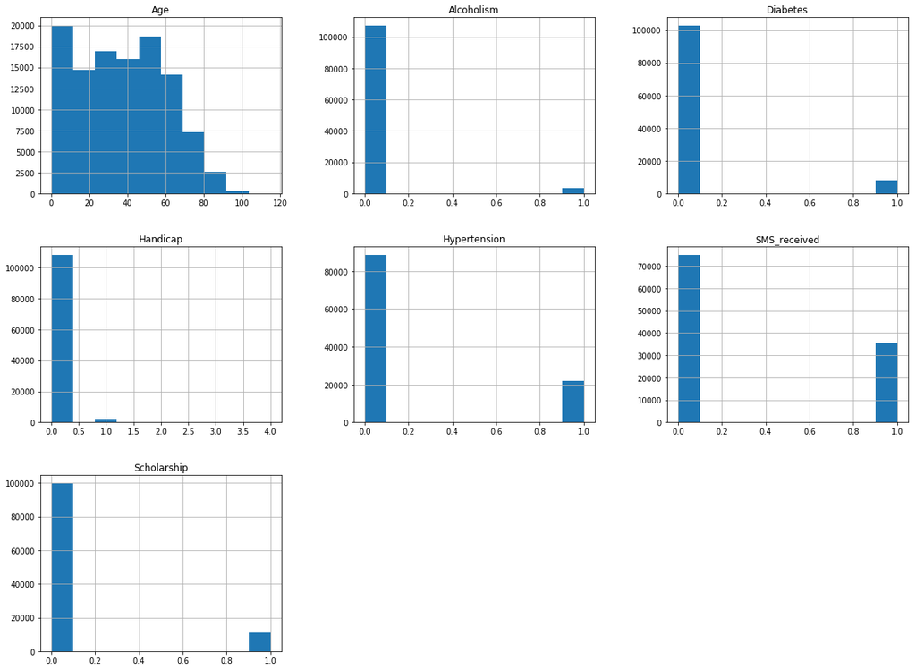

```python
df.hist(figsize = (20,15));
```

The Histograms allow us to say that Most Patients have no Special Health Conditions Like:

```
Diabetes

Alcoholism

Hypertension

Handicap
```

And Most Patients didn't receive a SMS and Have no Scholarship.

```python
df.Neighbourhood.value_counts()
```

```
JARDIM CAMBURI                 7717
MARIA ORTIZ                    5805
RESISTÊNCIA                    4431
JARDIM DA PENHA                3877
ITARARÉ                        3514
CENTRO                         3334
TABUAZEIRO                     3132
SANTA MARTHA                   3131
JESUS DE NAZARETH              2853
BONFIM                         2773
SANTO ANTÔNIO                  2746
SANTO ANDRÉ                    2571
CARATOÍRA                      2565
JABOUR                         2509
SÃO PEDRO                      2448
ILHA DO PRÍNCIPE               2266
NOVA PALESTINA                 2264
ANDORINHAS                     2262
DA PENHA                       2217
ROMÃO                          2214
GURIGICA                       2018
SÃO JOSÉ                       1977
BELA VISTA                     1907
MARUÍPE                        1902
FORTE SÃO JOÃO                 1889
ILHA DE SANTA MARIA            1885
SÃO CRISTÓVÃO                  1836
REDENÇÃO                       1553
SÃO BENEDITO                   1439
JOANA D´ARC                    1427
                               ...
SANTOS REIS                     547
ESTRELINHA                      538
SANTA CLARA                     506
SOLON BORGES                    469
PIEDADE                         452
SANTA CECÍLIA                   448
SANTA LÚCIA                     438
SANTA LUÍZA                     428
BARRO VERMELHO                  423
DO MOSCOSO                      413
MÁRIO CYPRESTE                  371
BOA VISTA                       312
COMDUSA                         310
DE LOURDES                      305
ARIOVALDO FAVALESSA             282
ANTÔNIO HONÓRIO                 271
FRADINHOS                       258
ENSEADA DO SUÁ                  235
SANTA HELENA                    178
HORTO                           175
UNIVERSITÁRIO                   152
SEGURANÇA DO LAR                145
NAZARETH                        135
MORADA DE CAMBURI                96
PONTAL DE CAMBURI                69
ILHA DO BOI                      35
ILHA DO FRADE                    10
AEROPORTO                         8
ILHAS OCEÂNICAS DE TRINDADE       2
PARQUE INDUSTRIAL                 1
Name: Neighbourhood, Length: 81, dtype: int64
```

```
Text(0.5,1,'Number of Patients In Each Neighbourhood')
```

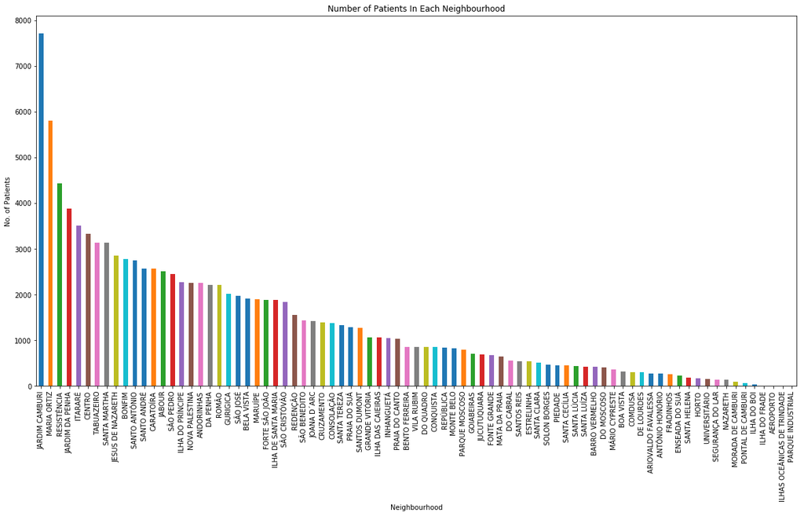

```python
df.Neighbourhood.value_counts().plot(kind = 'bar', figsize = (20,10));
plt.xlabel('Neighbourhood')
plt.ylabel('No. of Patients')
plt.title('Number of Patients In Each Neighbourhood')
```

We have 81 Neighbourhood with Various Number of Patients.

```python
def percent_and_pieplot(col):
    print(round(df[col].value_counts()/len(df)*100,2))
    df[col].value_counts().plot(kind = 'pie', figsize = (10,10), autopct = '%.2f%%', explode = (0,.05))
    plt.ylabel('Ratio')
    plt.title(col);
```

##### Gender Ratio:

```
F    65.0
M    35.0
Name: Gender, dtype: float64
```

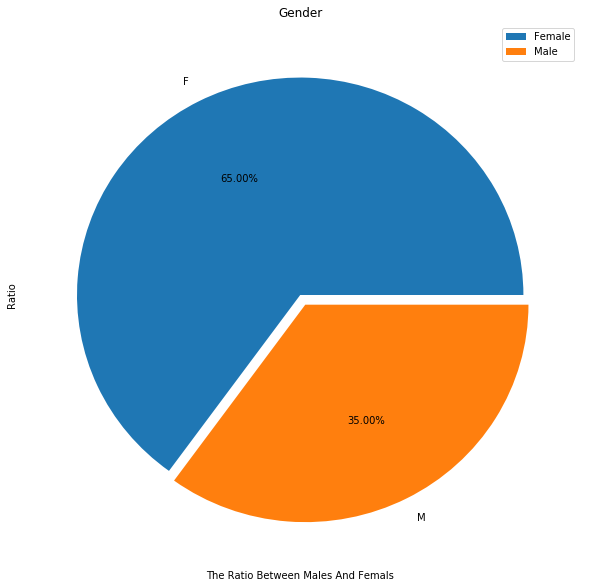

```python
percent_and_pieplot('Gender')
plt.xlabel('The Ratio Between Males And Femals')
plt.legend(['Female', 'Male'])
```

65% of Patients are Female and only 35% of them are Males

##### Scholarship Ratio:

```
0    90.17
1     9.83
Name: Scholarship, dtype: float64
```

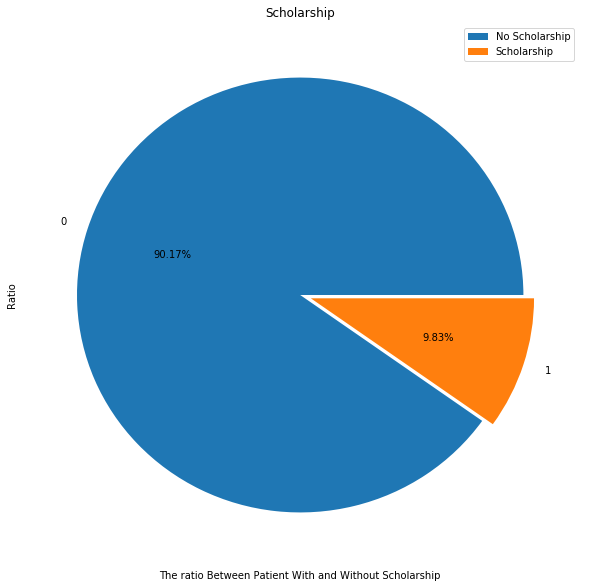

```python
percent_and_pieplot('Scholarship')
plt.xlabel('The ratio Between Patient With and Without Scholarship')
plt.legend(['No Scholarship', 'Scholarship'])
```

Almost 90% of Patients have no Scholarship and only 9.83% of them have one.

##### Hypertension Ratio:

```
0    80.28
1    19.72
Name: Hypertension, dtype: float64
```

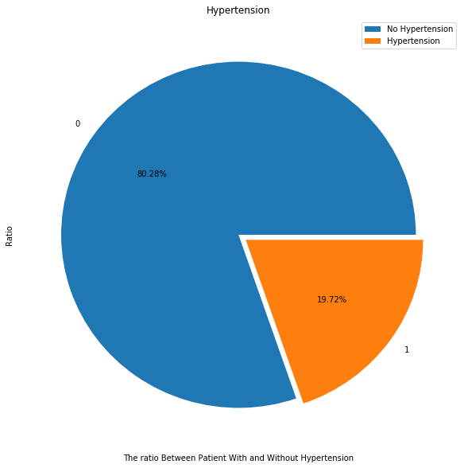

```python
percent_and_pieplot('Hypertension')
plt.xlabel('The ratio Between Patient With and Without Hypertension')
plt.legend(['No Hypertension', 'Hypertension'])
```

Almost 80% of Patients don't have Hypertension and Only 19.72% of them have it.

##### Diabetes Ratio:

```
0    92.81
1     7.19
Name: Diabetes, dtype: float64
```

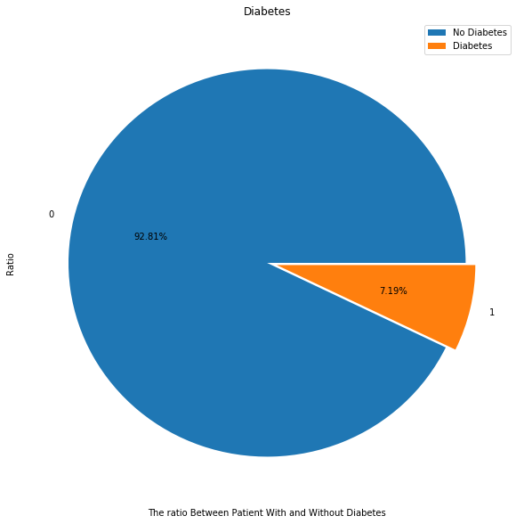

```python
percent_and_pieplot('Diabetes')
plt.xlabel('The ratio Between Patient With and Without Diabetes')
plt.legend(['No Diabetes', 'Diabetes'])
```

92.81% of Patients don't have Diabetes and Only 7.19% of them have it.

##### Alcoholism Ratio:

```
0    96.96
1     3.04
Name: Alcoholism, dtype: float64
```

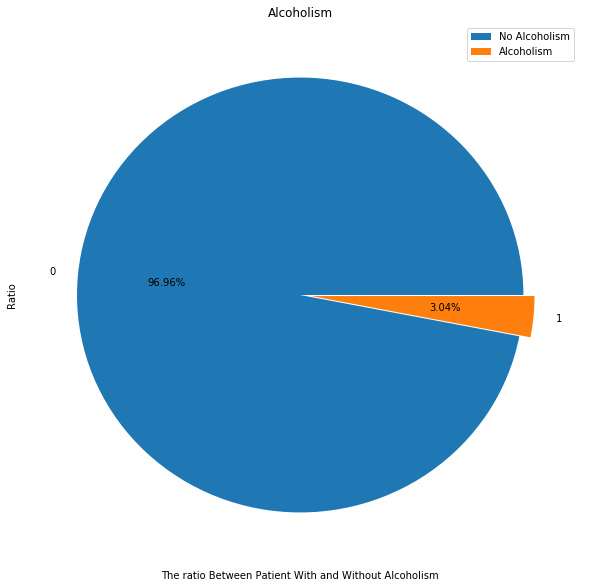

```python
percent_and_pieplot('Alcoholism')
plt.xlabel('The ratio Between Patient With and Without Alcoholism')
plt.legend(['No Alcoholism', 'Alcoholism'])
```

96.96% of Patients aren't Alcoholic and Only 3.04% of them are.

##### SMS_received Ratio:

```
0    67.9
1    32.1
Name: SMS_received, dtype: float64
```

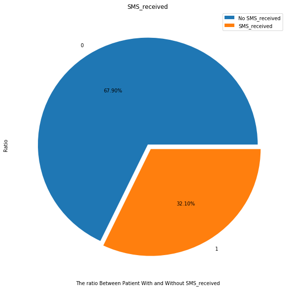

```python
percent_and_pieplot('SMS_received')
plt.xlabel('The ratio Between Patient With and Without SMS_received')
plt.legend(['No SMS_received', 'SMS_received'])
```

Only 32.1% of Pattients received SMS and 67.90% of them didn't receive it.

##### No Show Ratio:

```
No     79.81
Yes    20.19
Name: No_show, dtype: float64
```

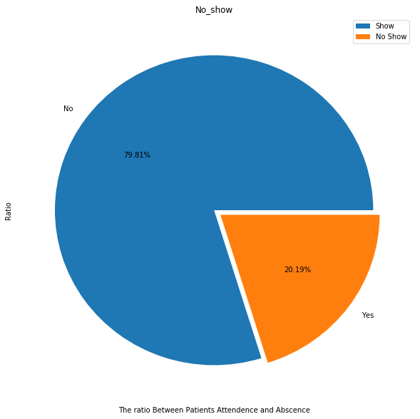

```python
percent_and_pieplot('No_show')
plt.xlabel('The ratio Between Patients Attendence and Abscence')
plt.legend(['Show','No Show'])
```

79.81% of Patients showed up for their Appointments and only 20.19 of them did not.

```python
#Adding Mask for using it later
No_show = df['No_show'] == 'Yes'
Show = df['No_show'] == 'No'
```

## First Question: Is There a Strong Relationship Between The Gender of Patients and Missing the Appointments?

```
F    57245
M    30962
Name: Gender, dtype: int64
F    14594
M     7725
Name: Gender, dtype: int64
The Percentage of Females with No_show Appointments =  20.31
The Percentage of Males with No_show Appointments =  19.97
```

```
Text(0.5,1,'The Percentage Of Show and No show Patients Based on Gender')
```

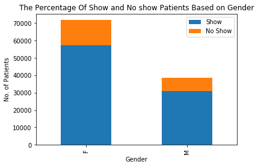

```python
print(df.Gender[Show].value_counts())
print(df.Gender[No_show].value_counts())
Gender_Count = df.groupby('Gender')['No_show'].value_counts()
print('The Percentage of Females with No_show Appointments = ', round(Gender_Count[1]/(Gender_Count[0]+Gender_Count[1])*100,2))
print('The Percentage of Males with No_show Appointments = ', round(Gender_Count[3]/(Gender_Count[3]+Gender_Count[2])*100,2))
df.groupby('Gender')['No_show'].value_counts().unstack().plot(kind = 'bar', stacked = True)
plt.legend(['Show', 'No Show'])
plt.ylabel('No. of Patients')
plt.title('The Percentage Of Show and No show Patients Based on Gender')
```

### Results:

The Percentage of No Show Patients Based on Gender is insigntificant. percentage of Females with no Show appointments is 20.31% while males is 19.97% So, We Could Say There's No Strong Relatonship Between Gender and Missing the Appointments.

## Second Question: Is There a Strong Relationship Between The Age of Patients and Missing the Appointments?

```
Text(0.5,1,'Age_Attendance Histogram')
```

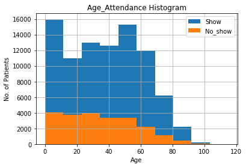

```python
df.Age[Show].hist(bins = 10, label = 'Show')
df.Age[No_show].hist(bins = 10, label = 'No_show')
plt.legend()
plt.xlabel('Age')
plt.ylabel('No. of Patients')
plt.title('Age_Attendance Histogram')
```

Every Age has a Different Number of Patients with different Attendance.

```
0      2900
1      1858
52     1449
56     1372
2      1366
59     1357
49     1354
53     1332
57     1325
50     1322
38     1309
51     1284
54     1262
3      1236
36     1236
```

[output cut: 109 more lines]

```
Text(0.5,1,'The Percentage Of Show and No show Patients Based on Age')
```

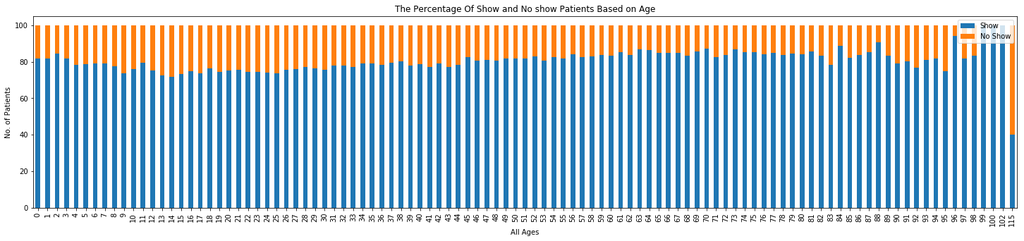

```python
print(df.Age[Show].value_counts())
print(df.Age[No_show].value_counts())
Age_Count = df.groupby('Age')['No_show'].value_counts()
Age_Count.groupby(level=0).sum()
round(Age_Count/Age_Count.groupby(level=0).sum()*100,2).unstack().plot(kind = 'bar', stacked = True, figsize =(25,5))
plt.legend(['Show', 'No Show'])
plt.ylabel('No. of Patients')
plt.xlabel('All Ages')
plt.title('The Percentage Of Show and No show Patients Based on Age')
```

This Figure allows us to see How Every Single Age has a Different Percentage Between Show and No Show Patients.

```python
bins = [0,12,18,35,50,65,115]
bin_names = ['Kids (0-11)', 'Teenagers (12-18)', 'Young Adults (19-35)', 'Adult (36-50)','Middle-Age Adults (51-65)','Senior Adult (66-115)']
Age_Stages = pd.cut(df.Age, bins = bins, labels = bin_names)
df.insert(7, 'Age_Stages', Age_Stages)
df.head()
```

|  | Gender | ScheduledDay | AppointmentDay | Age | Neighbourhood | Scholarship | Hypertension | Age_Stages | Diabetes | Alcoholism | Handicap | SMS_received | No_show |
| --- | --- | --- | --- | --- | --- | --- | --- | --- | --- | --- | --- | --- | --- |
| 0 | F | 2016-04-29 18:38:08 | 2016-04-29 | 62 | JARDIM DA PENHA | 0 | 1 | Middle-Age Adults (51-65) | 0 | 0 | 0 | 0 | No |
| 1 | M | 2016-04-29 16:08:27 | 2016-04-29 | 56 | JARDIM DA PENHA | 0 | 0 | Middle-Age Adults (51-65) | 0 | 0 | 0 | 0 | No |
| 2 | F | 2016-04-29 16:19:04 | 2016-04-29 | 62 | MATA DA PRAIA | 0 | 0 | Middle-Age Adults (51-65) | 0 | 0 | 0 | 0 | No |
| 3 | F | 2016-04-29 17:29:31 | 2016-04-29 | 8 | PONTAL DE CAMBURI | 0 | 0 | Kids (0-11) | 0 | 0 | 0 | 0 | No |
| 4 | F | 2016-04-29 16:07:23 | 2016-04-29 | 56 | JARDIM DA PENHA | 0 | 1 | Middle-Age Adults (51-65) | 1 | 0 | 0 | 0 | No |

```
Text(0,0.5,'No. of Patients')
```

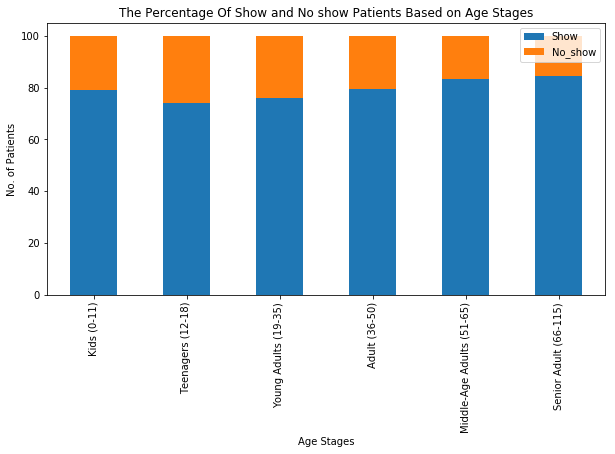

```python
Age_Stages_Count = df.groupby('Age_Stages')['No_show'].value_counts()
Age_Stages_Count.groupby(level=0).sum()
round(Age_Stages_Count/Age_Stages_Count.groupby(level=0).sum()*100,2).unstack().plot(kind = 'bar', stacked = True, figsize =(10,5))
plt.legend(['Show','No_show'])
plt.title('The Percentage Of Show and No show Patients Based on Age Stages')
plt.xlabel('Age Stages')
plt.ylabel('No. of Patients')
```

We Put Ages into Stages to Make it Easier and More Obvious to Answer our Question.

```
Text(0,0.5,'No. of Patients')
```

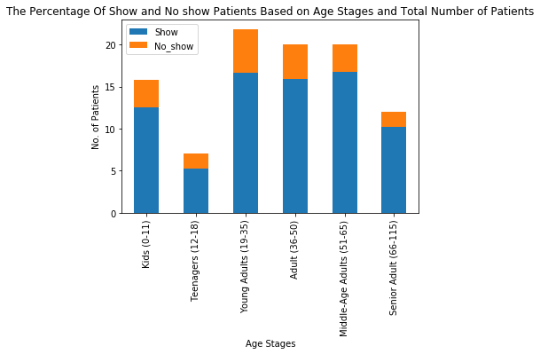

```python
(Age_Stages_Count/len(df)*100).unstack().plot(kind = 'bar', stacked = True);
plt.legend(['Show','No_show'])
plt.title('The Percentage Of Show and No show Patients Based on Age Stages and Total Number of Patients')
plt.xlabel('Age Stages')
plt.ylabel('No. of Patients')
```

### Results:

There's No Strong Relationship Between Age and Missing The Appointment.

But, We Could Say that Kids and Adults Over 50s are More likely to Not Miss Their Appointments.

And Teenagers and Young Adult Patients from 12 to 35 are More Likely to Miss Their Appointments.

## Third Question: Is There a Strong Relationship Between The Neighbourhood of Patients and Missing the Appointments?

```
Text(0,0.5,'No. of Patients')
```

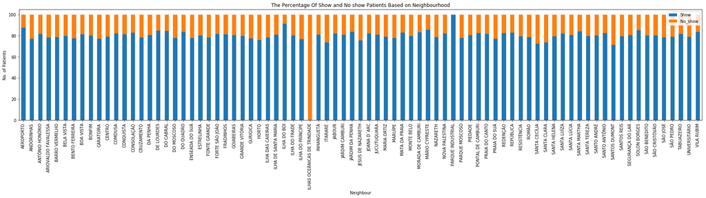

```python
Neighbourhood_Count = df.groupby('Neighbourhood')['No_show'].value_counts()
round(Neighbourhood_Count/Neighbourhood_Count.groupby(level=0).sum()*100,2).unstack().plot(kind = 'bar', stacked = True, figsize =(30,5))
plt.legend(['Show','No_show'])
plt.title('The Percentage Of Show and No show Patients Based on Neighbourhood')
plt.xlabel('Neighbour')
plt.ylabel('No. of Patients')
```

```
Text(0,0.5,'No. of Patients')
```

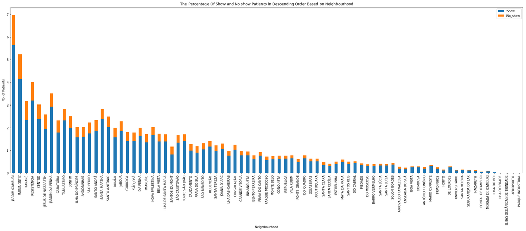

```python
round(Neighbourhood_Count/len(df)*100,2).unstack().sort_values(by = 'Yes', ascending = False).plot(kind = 'bar', stacked = True, figsize = (30,10));
plt.legend(['Show','No_show'])
plt.title('The Percentage Of Show and No show Patients in Descending Order Based on Neighbourhood')
plt.xlabel('Neighbourhood')
plt.ylabel('No. of Patients')
```

This Figure Allows Us to See the Ratio Between Patients Who Missed their Appointments and who Didn't miss them in a Descending Order Based on Their Neighbourhood

### Results:

There's No Strong Relationship Between Neighbourhood and Missing the Appointments.

But We Could Say That The Neighbourhoods with The greatest Number of Patients have the greatest Number of Missed Appointements.

## Conclusions

There's No Strong Relatonship Between Gender and Missing the Appointments.

The Percentage Between Males and Females With No show Appointments is pretty Close.

Females = 20.31, Males = 19.97.

Kids and Adults Over 50s are More likely to Not Miss Their Appointments.

And Teenagers and Young Adult Patients from 12 to 35 are More Likely to Miss Their Appointments.

The Neighbourhoods with The greatest Number of Patients have the greatest Number of Missed Appointements.

But There's No Correlation Between Neighbourhood and Missing the Appointments.

Most Patients:

. Females

. Young

. With No Scholarship

. With No Special Conditions Like: Hypertension, Diabetes, Alcoholism, Handicap

. With No SMS_received. 67.90% of Patients didn't Received a SMS

. 79.81% of Patients Didn't Miss Their Appointments

## Limitations

The Time Between the First And Last AppointementDay is only 2 Months. This short Period of Time is not enough or reliable to make a strong correlation.

Abscence of Other Data That Could be Useful Like The Employment Status, The Medical Issue Urgency.

There's No Explanation How the Data was Collected.

```python
from subprocess import call
call(['python', '-m', 'nbconvert', 'Investigate_a_Dataset.ipynb'])
```

```
0
```